# Study 1: Reinforcement-Punishment Analysis

Debbie Yee

3/18/2018

# Study 1: Punishment Effects of Monetary and Liquid Incentives

This is an analysis of the subject performance of study 1 of reinforcement and punishment effects of liquid feedback with monetary gains and losses. In the study, subjects perform the cued task-switching paradigm, where they have classify a letter (vowel/consonant) or digit (odd/even). During the baseline runs, they don’t receive any feedback and are told to respond “as quickly and accurate as possible.” During the incentive runs, they receive a drop of liquid (2 mL) to indicate successful attainment of monetary reward in a single trial. Each subject performs 3 incentive runs in which they must respond accurately and faster than a criterion RT to earn monetary reward. Liquid feedback (blocked) signaled failure to attain monetary reward (opportunity cost). Criterion RT is calculated on subject performance during the baseline run (25%) (CHECK THIS), and is the same for both reinforcement and punishment conditions.

# Loading relevant packages

```r
library(ggplot2)
library(gridExtra)
library(dplyr)
library(tidyr)
library(lme4)
library(lmerTest)
library(sjPlot)
library(pander)
source("summarySEwithin2.R")
```

# Path Directories of Data Input/Output

```r
# data directories
data.path<-paste0("/Users/debbieyee/Dropbox/CCPLabProjects/Liquid_Feedback/",
                  "Reinforce-Punish_Combined/Study1/Data/SubjectData/TrimmedData/",
                  "NewCT/Study1_RewardData.csv")
runkey.path<-paste0("/Users/debbieyee/Dropbox/CCPLabProjects/Liquid_Feedback/",
                    "Reinforce-Punish_Combined/Study1/Data/SubjectData/TrimmedData/",
                    "NewCT/Study1_runkey.csv")
figure.path<-paste0("/Users/debbieyee/Dropbox/CCPLabProjects/Liquid_Feedback/",
                    "Reinforce-Punish_Combined/Study1/Analysis/Figures/")
```

# Format the Data For Analysis

```r
# Read in the data
data<-read.csv(data.path,header = TRUE) %>% select(-X)
runkey<-read.csv(runkey.path, header = TRUE) %>% select(-X)

# Formatting incentive data
incentive<- data %>% inner_join(y = runkey, by = c("subID","block"))  %>%
  mutate(subRewarded=(RT<critRT & ACC==1)*1,
         ERR=ifelse(ACC==0,1,0),
         block=factor(block, levels=c(7,8,9), labels=c(1,2,3)),
         money=factor(rewType, levels=c("Reward1","Reward2","Reward4"), labels=c("$","$$","$$$$")),
         moneyCode=factor(rewType, levels=c("Reward1","Reward2","Reward4"), labels=c(-1,0,1)),
         liqCode=factor(liquid, levels=c("saltwater","neutral","juice"), labels=c(-1,0,1)),
         liqCodeJvN=factor(liquid, levels=c("saltwater","neutral","juice"), labels=c(0,-1,1)),
         liqCodeSvN=factor(liquid, levels=c("saltwater","neutral","juice"), labels=c(-1,1,0)))
incentive$moneyCode<-as.numeric(levels(incentive$moneyCode)[incentive$moneyCode])
incentive$liqCode<-as.numeric(levels(incentive$liqCode)[incentive$liqCode])
incentive$liqCodeJvN<-as.numeric(levels(incentive$liqCodeJvN)[incentive$liqCodeJvN])
incentive$liqCodeSvN<-as.numeric(levels(incentive$liqCodeSvN)[incentive$liqCodeSvN])
```

# Summarise/Consolidate Incentive Data

```r
# summarise means by monetary reward only
rewRT.means = incentive %>% group_by(subID, money) %>%
  filter(!is.na(subRewarded), ACC==1) %>% filter(!is.na(subRewarded), ACC==1) %>%
  summarise(n=n(),meanRT = mean(RT))
rew.means = incentive %>% group_by(subID,money) %>% filter(!is.na(subRewarded)) %>%
  summarise(n=n(), meanRR = mean(subRewarded), meanACC = mean(ACC), meanERR = mean(ERR))

# summarise means by liquid incentive type only
liqRT.means = incentive %>% group_by(subID, liquid) %>% filter(!is.na(subRewarded), ACC==1) %>%
  summarise(meanRT = mean(RT))
liq.means=incentive %>% group_by(subID, liquid) %>% filter(!is.na(subRewarded)) %>%
  summarise(n=n(), meanRR = mean(subRewarded), meanACC = mean(ACC), meanERR = mean(ERR))

# summarise the means of the incentive data for each subject, grouped by condition
incentive9RT.means <- incentive %>% group_by(subID, liquid, money) %>%
  filter(!is.na(subRewarded), ACC==1) %>% summarise(n=n(), meanRT = mean(RT)) %>%
  mutate(moneycode = as.numeric(as.character(factor(money,levels=c("$","$$","$$$$"),
                                                    labels=c(-1,0,1)))),
         liqcode = as.numeric(as.character(factor(liquid,levels=c("saltwater","neutral","juice"),
                                                  labels=c(-1,0,1))))) %>%
  ungroup(subID) %>% mutate(subID=as.factor(subID))
incentive9.means = incentive %>% group_by(subID, liquid, money) %>% filter(!is.na(subRewarded)) %>%
  summarise(n = n(), meanRR = mean(subRewarded), meanACC = mean(ACC), meanERR = mean(ERR)) %>%
  mutate(moneycode = as.numeric(as.character(factor(money,levels=c("$","$$","$$$$"),
                                                    labels=c(-1,0,1)))),
         liqcode = as.numeric(as.character(factor(liquid,levels=c("saltwater","neutral","juice"),
                                                  labels=c(-1,0,1))))) %>%
  ungroup(subID) %>% mutate(subID=as.factor(subID))
```

# Reward Rate Plots

## Plot: mean reward rate by monetary reward level

```r
RR.sum=summarySEwithin2(data=rew.means, measurevar = "meanRR", withinvars = c("money"),
                        idvar = "subID")
pandoc.table(RR.sum)
```

```
##
## -------------------------------------------------------------------
##  money   N    meanRR   meanRRNormed     sd         se        ci
## ------- ---- -------- -------------- --------- ---------- ---------
##    $     39   0.668       0.668       0.05132   0.008218   0.01664
##
##   $$     39   0.6787      0.6787      0.04878   0.007811   0.01581
##
##  $$$$    39   0.7236      0.7236      0.05154   0.008252   0.01671
## -------------------------------------------------------------------
```

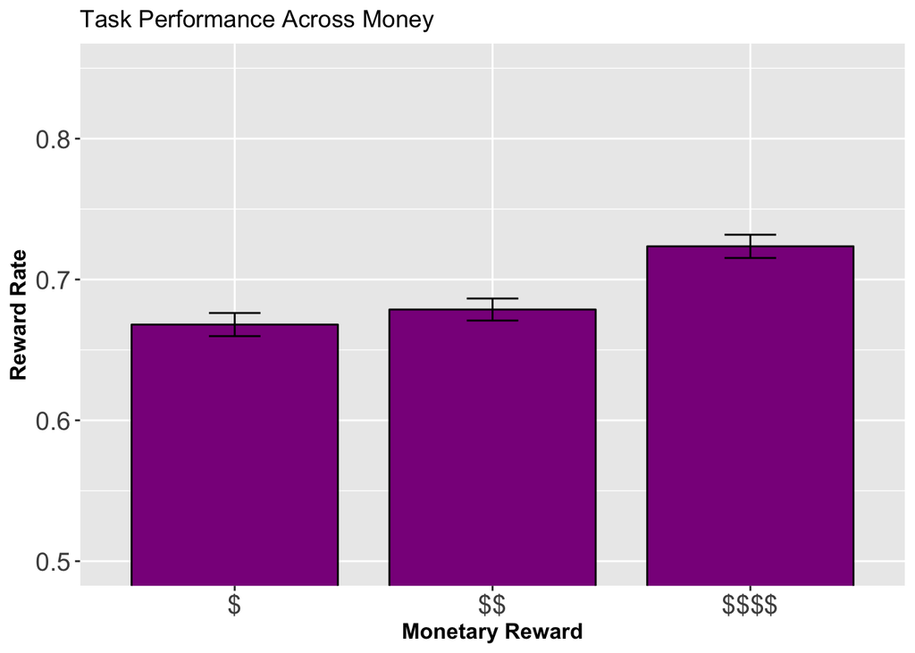

```r
p.RR.1<-ggplot(RR.sum, aes(x=money, y=meanRR)) +
  geom_bar(position=position_dodge(width=0.8), color="black",
           fill='darkmagenta', stat="identity", width=0.8) +
  geom_errorbar(position=position_dodge(width=0.8),
                aes(ymin=meanRR-se, ymax=meanRR+se), width=.2) +
  xlab("Monetary Reward") + ylab("Reward Rate") +
  ggtitle("Task Performance Across Money") +
  coord_cartesian(ylim=c(.5,.85)) +
  scale_fill_discrete(name="Monetary Reward") +
  theme(#plot.title=element_text(size=22,face="bold", vjust=2),
        axis.title=element_text(size=12,face = "bold"),
        axis.text=element_text(size=14),
        legend.position="none",
        strip.text.x = element_text(size = 12))
p.RR.1
```

## Plot: mean reward rate by liquid type

```r
RR.sum=summarySEwithin2(data=liq.means, measurevar = "meanRR", withinvars = c("liquid"),
                        idvar = "subID")
pandoc.table(RR.sum)
```

```
##
## -----------------------------------------------------------------------
##   liquid     N    meanRR   meanRRNormed     sd         se        ci
## ----------- ---- -------- -------------- --------- ---------- ---------
##    juice     39   0.6782      0.6782      0.06493    0.0104    0.02105
##
##   neutral    39   0.6827      0.6827      0.06098   0.009765   0.01977
##
##  saltwater   39   0.7094      0.7094      0.05644   0.009038   0.0183
## -----------------------------------------------------------------------
```

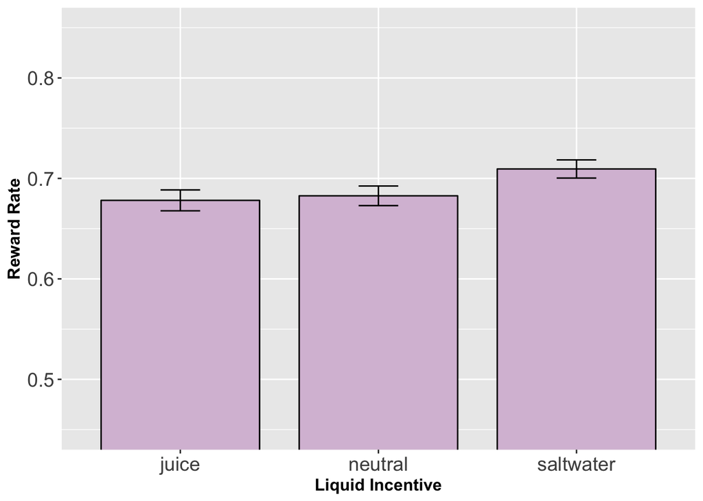

```r
p.RR.2<-ggplot(RR.sum, aes(x=liquid, y=meanRR)) +
  geom_bar(position=position_dodge(width=0.8), color="black", fill='thistle',
           stat="identity", width=0.8) +
  geom_errorbar(position=position_dodge(width=0.8),
                aes(ymin=meanRR-se, ymax=meanRR+se), width=.2) +
  xlab("Liquid Incentive") + ylab("Reward Rate") +
  #ggtitle("Task Performance Across Liquid Type") +
  coord_cartesian(ylim=c(.45,.85)) +
  scale_fill_discrete(name="Monetary Reward") +
  theme(#plot.title=element_text(size=22,face="bold", vjust=2),
        axis.title=element_text(size=12,face = "bold"),
        axis.text=element_text(size=14),
        legend.position="none",
        strip.text.x = element_text(size = 12))
p.RR.2
```

## Plot: mean reward rate by money and liquid type

```r
RR.sum=summarySEwithin2(data=incentive9.means, measurevar = "meanRR",
                        withinvars = c("money","liquid"), idvar = "subID")
pandoc.table(RR.sum)
```

```
##
## ------------------------------------------------------------------------------
##  money    liquid     N    meanRR   meanRRNormed     sd        se        ci
## ------- ----------- ---- -------- -------------- --------- --------- ---------
##    $       juice     39   0.641       0.641       0.08364   0.01339   0.02711
##
##    $      neutral    39   0.6747      0.6747      0.08896   0.01424   0.02884
##
##    $     saltwater   39   0.6883      0.6883      0.07842   0.01256   0.02542
##
##   $$       juice     39   0.6691      0.6691      0.1012    0.01621   0.03281
##
##   $$      neutral    39   0.6627      0.6627      0.09277   0.01486   0.03007
##
##   $$     saltwater   39   0.7043      0.7043      0.09359   0.01499   0.03034
##
##  $$$$      juice     39   0.7244      0.7244      0.09967   0.01596   0.03231
##
##  $$$$     neutral    39   0.7107      0.7107      0.08814   0.01411   0.02857
##
##  $$$$    saltwater   39   0.7356      0.7356      0.08412   0.01347   0.02727
## ------------------------------------------------------------------------------
```

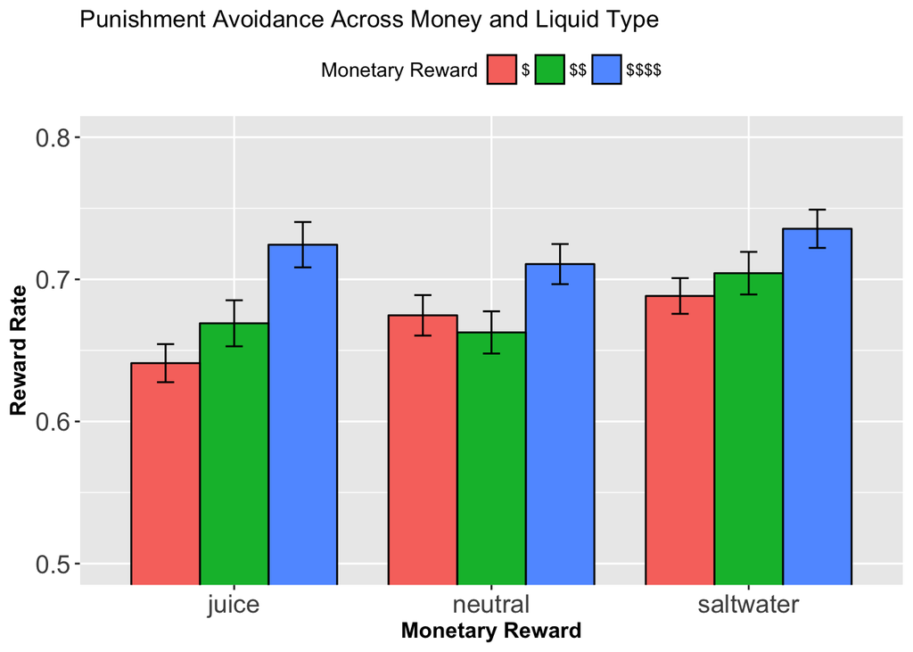

```r
# first plot
p.RR.3<-ggplot(RR.sum, aes(x=liquid, y=meanRR, fill=money)) +
  geom_bar(position=position_dodge(width=0.8), color="black",
           stat="identity", width=0.8) +
  geom_errorbar(position=position_dodge(width=0.8),
                aes(ymin=meanRR-se, ymax=meanRR+se), width=.2) +
  xlab("Monetary Reward") + ylab("Reward Rate") +
  ggtitle("Punishment Avoidance Across Money and Liquid Type") +
  coord_cartesian(ylim=c(.5,.8)) +
  scale_fill_discrete(name="Monetary Reward") +
  theme(#plot.title=element_text(size=22,face="bold", vjust=2),
        axis.title=element_text(size=12,face = "bold"),
        axis.text=element_text(size=14),
        legend.position="top",
        strip.text.x = element_text(size = 12))
p.RR.3
```

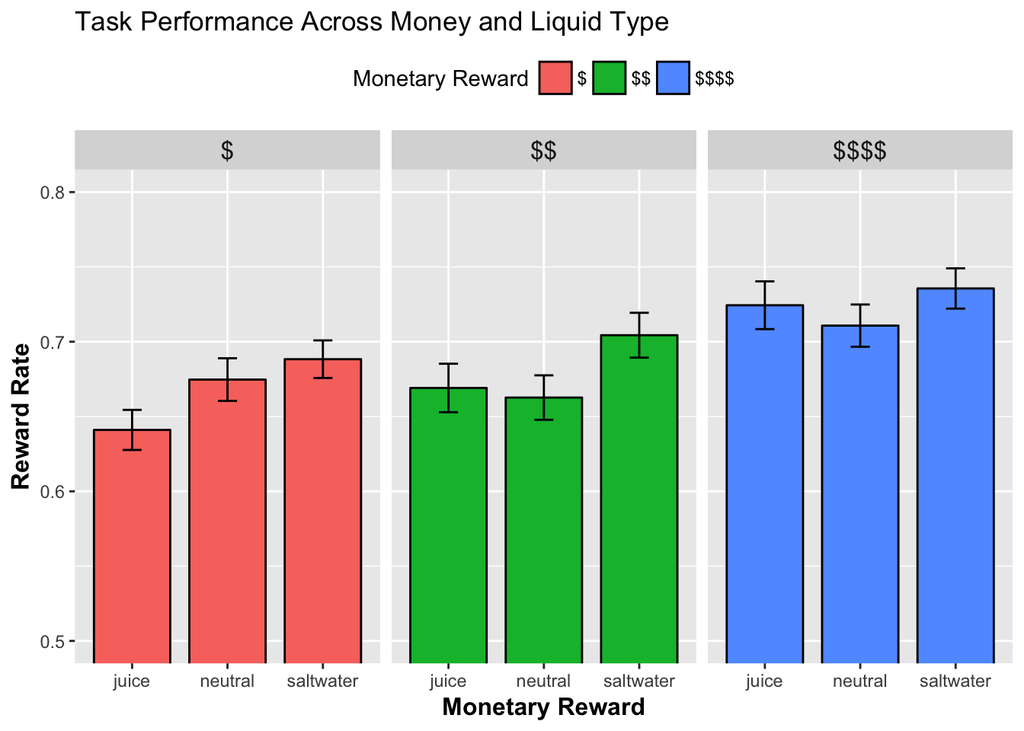

```r
# second plot
p.RR.4<-ggplot(RR.sum, aes(x=liquid, y=meanRR, fill=money)) +
  geom_bar(position=position_dodge(width=0.8), color="black", stat="identity", width=0.8) +
  geom_errorbar(position=position_dodge(width=0.8), aes(ymin=meanRR-se, ymax=meanRR+se), width=.2) +
  facet_wrap(~money) +
  xlab("Monetary Reward") + ylab("Reward Rate") +
  ggtitle("Task Performance Across Money and Liquid Type") +
  coord_cartesian(ylim=c(.5,.8)) +
  scale_fill_discrete(name="Monetary Reward") +
  theme(#plot.title=element_text(size=22,face="bold", vjust=2),
        axis.title=element_text(size=12,face = "bold"),
        #axis.text=element_text(size=14),
        legend.position="top",
        strip.text.x = element_text(size = 12))
p.RR.4
```

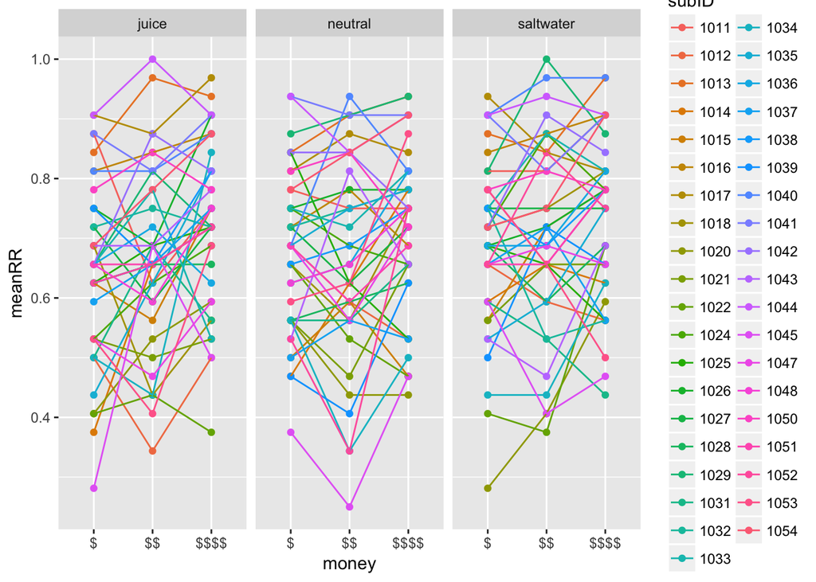

```r
ggplot(data = incentive9.means, mapping = aes(x = money, y = meanRR, col=subID, group=subID)) +
  facet_grid(~liquid) +
  geom_point() +
  geom_line()
```

# Generalized Linear Mixed Effects Models of Reward Rate Effects by Condition (Money, Liquid)

## Reward Rate by money (1,2,4) and liquid (juice,neutral,saltwater).

```r
# omnibus model: reward rate by liquid and money
m.RR.null<-glmer(formula = subRewarded ~ (1+moneyCode+liqCode|subID),
                  data = incentive, family=binomial)
m.RR.1<-glmer(formula = subRewarded ~ moneyCode*liqCode +(1+moneyCode+liqCode|subID),
              data = incentive, family=binomial)
summary(m.RR.1)
```

```
## Generalized linear mixed model fit by maximum likelihood (Laplace
##   Approximation) [glmerMod]
##  Family: binomial  ( logit )
## Formula: subRewarded ~ moneyCode * liqCode + (1 + moneyCode + liqCode |
##     subID)
##    Data: incentive
##
##      AIC      BIC   logLik deviance df.resid
##  13236.1  13309.4  -6608.1  13216.1    11222
##
## Scaled residuals:
##    Min     1Q Median     3Q    Max
## -3.479 -1.093  0.498  0.713  1.200
##
## Random effects:
##  Groups Name        Variance Std.Dev. Corr
##  subID  (Intercept) 0.408597 0.63922
##         moneyCode   0.004809 0.06934   0.16
##         liqCode     0.019613 0.14005  -0.23  0.58
## Number of obs: 11232, groups:  subID, 39
##
## Fixed effects:
##                   Estimate Std. Error z value Pr(>|z|)
## (Intercept)        0.88715    0.10488   8.458  < 2e-16 ***
## moneyCode          0.14726    0.02928   5.030 4.91e-07 ***
## liqCode           -0.08298    0.03519  -2.358   0.0184 *
## moneyCode:liqCode  0.04317    0.03187   1.354   0.1756
## ---
## Signif. codes:  0 '***' 0.001 '**' 0.01 '*' 0.05 '.' 0.1 ' ' 1
##
## Correlation of Fixed Effects:
##             (Intr) monyCd liqCod
## moneyCode    0.080
## liqCode     -0.151  0.147
## monyCd:lqCd  0.001 -0.026  0.036
## convergence code: 0
## Model failed to converge with max|grad| = 0.340106 (tol = 0.001, component 1)
```

## Reward Rate separated by Monetary Reward

```r
# Monetary Reward Effect
m.RR.1.money <-glmer(formula = subRewarded ~ moneyCode + (1+moneyCode|subID),
          data = incentive, family = binomial)
summary(m.RR.1.money)
```

```
## Generalized linear mixed model fit by maximum likelihood (Laplace
##   Approximation) [glmerMod]
##  Family: binomial  ( logit )
## Formula: subRewarded ~ moneyCode + (1 + moneyCode | subID)
##    Data: incentive
##
##      AIC      BIC   logLik deviance df.resid
##  13245.4  13282.0  -6617.7  13235.4    11227
##
## Scaled residuals:
##     Min      1Q  Median      3Q     Max
## -3.2969 -1.0958  0.5006  0.7131  1.1615
##
## Random effects:
##  Groups Name        Variance Std.Dev. Corr
##  subID  (Intercept) 0.384207 0.61984
##         moneyCode   0.006252 0.07907  0.09
## Number of obs: 11232, groups:  subID, 39
##
## Fixed effects:
##             Estimate Std. Error z value Pr(>|z|)
## (Intercept)  0.87744    0.10168   8.630  < 2e-16 ***
## moneyCode    0.14101    0.02972   4.745 2.08e-06 ***
## ---
## Signif. codes:  0 '***' 0.001 '**' 0.01 '*' 0.05 '.' 0.1 ' ' 1
##
## Correlation of Fixed Effects:
##           (Intr)
## moneyCode 0.049
```

```r
# Money $ (Low)
m.RR.1.money.rew1 <-glmer(formula = subRewarded ~ liqCode + (1+liqCode|subID),
          data = subset(incentive, moneyCode==-1), family = binomial)
summary(m.RR.1.money.rew1)
```

```
## Generalized linear mixed model fit by maximum likelihood (Laplace
##   Approximation) [glmerMod]
##  Family: binomial  ( logit )
## Formula: subRewarded ~ liqCode + (1 + liqCode | subID)
##    Data: subset(incentive, moneyCode == -1)
##
##      AIC      BIC   logLik deviance df.resid
##   4598.5   4629.6  -2294.2   4588.5     3739
##
## Scaled residuals:
##     Min      1Q  Median      3Q     Max
## -2.8898 -1.0972  0.5548  0.7210  1.1730
##
## Random effects:
##  Groups Name        Variance  Std.Dev. Corr
##  subID  (Intercept) 0.3412307 0.584150
##         liqCode     0.0000835 0.009138 -1.00
## Number of obs: 3744, groups:  subID, 39
##
## Fixed effects:
##             Estimate Std. Error z value Pr(>|z|)
## (Intercept)  0.75829    0.10057   7.540 4.69e-14 ***
## liqCode     -0.11562    0.04503  -2.568   0.0102 *
## ---
## Signif. codes:  0 '***' 0.001 '**' 0.01 '*' 0.05 '.' 0.1 ' ' 1
##
## Correlation of Fixed Effects:
##         (Intr)
## liqCode -0.045
```

```r
# Money $$ (Medium)
m.RR.1.money.rew2 <-glmer(formula = subRewarded ~ liqCode + (1+liqCode|subID),
          data = subset(incentive,moneyCode==0), family = binomial)
summary(m.RR.1.money.rew2)
```

```
## Generalized linear mixed model fit by maximum likelihood (Laplace
##   Approximation) [glmerMod]
##  Family: binomial  ( logit )
## Formula: subRewarded ~ liqCode + (1 + liqCode | subID)
##    Data: subset(incentive, moneyCode == 0)
##
##      AIC      BIC   logLik deviance df.resid
##   4481.0   4512.1  -2235.5   4471.0     3739
##
## Scaled residuals:
##     Min      1Q  Median      3Q     Max
## -3.1746 -1.0368  0.4716  0.7211  1.1776
##
## Random effects:
##  Groups Name        Variance Std.Dev. Corr
##  subID  (Intercept) 0.47453  0.6889
##         liqCode     0.04082  0.2020   -0.17
## Number of obs: 3744, groups:  subID, 39
##
## Fixed effects:
##             Estimate Std. Error z value Pr(>|z|)
## (Intercept)  0.83915    0.11682   7.183 6.81e-13 ***
## liqCode     -0.09574    0.05697  -1.680   0.0929 .
## ---
## Signif. codes:  0 '***' 0.001 '**' 0.01 '*' 0.05 '.' 0.1 ' ' 1
##
## Correlation of Fixed Effects:
##         (Intr)
## liqCode -0.105
```

```r
# Money $$$$ (High)
m.RR.1.money.rew4 <-glmer(formula = subRewarded ~ liqCode + (1+liqCode|subID),
          data = subset(incentive,moneyCode==1), family = binomial)
summary(m.RR.1.money.rew4)
```

```
## Generalized linear mixed model fit by maximum likelihood (Laplace
##   Approximation) [glmerMod]
##  Family: binomial  ( logit )
## Formula: subRewarded ~ liqCode + (1 + liqCode | subID)
##    Data: subset(incentive, moneyCode == 1)
##
##      AIC      BIC   logLik deviance df.resid
##   4276.2   4307.3  -2133.1   4266.2     3739
##
## Scaled residuals:
##     Min      1Q  Median      3Q     Max
## -3.3836 -1.1024  0.5072  0.6415  1.0061
##
## Random effects:
##  Groups Name        Variance Std.Dev. Corr
##  subID  (Intercept) 0.34947  0.5912
##         liqCode     0.02703  0.1644   -0.20
## Number of obs: 3744, groups:  subID, 39
##
## Fixed effects:
##             Estimate Std. Error z value Pr(>|z|)
## (Intercept)  1.04232    0.10259  10.160   <2e-16 ***
## liqCode     -0.03836    0.05493  -0.698    0.485
## ---
## Signif. codes:  0 '***' 0.001 '**' 0.01 '*' 0.05 '.' 0.1 ' ' 1
##
## Correlation of Fixed Effects:
##         (Intr)
## liqCode -0.098
```